# Data_Science_Project (1)

The Project can be accessed here kalucira.github.io  
$\textbf{CIRUS KALUGANA}$  
$\textbf{Tulane University}$  
$\textbf{Data Science Course Final Project}$  
$\textbf{Project Milestone 2}$  
$\textbf{11/19/2022}$

$\textbf{Project Goals:}$

The goal of this project is to explore the temporal and spatial distribution of earthquakes around New Zealand from 1990 - 2022, and investigate the possible relation with the motion of the subducting tectonic plates.  
The motivation of this project the series of migrating seismic swarms of small and medium size magnitude earthquakes which have been happening around New Zealand, with the country recording up to 15000 earthquakes per year.  
In this project I will be working alone as required for graduate students and do hope to be working on it whenever time is available as planned.  
$\textbf{Project Explanations:}$  
This project requires two sets of data, the first one about the earthquakes in the study region and the seond set of data about the motion of the plates on which New Zealand is seated.  
The first set of data was obtained from the data management centre called [Incorporated Research Institutions for Seismology - IRIS](https://service.iris.edu/). The data was acquired by downloading it using a code from Observational Python library called [ObsPy](https://docs.obspy.org/) as shown in the following cells.  
The second set of data about the motion of the plates is the Global Positioning System (GPS) data recorded by GPS stations from different parts of the region in New Zealand. This data was obtained from [Nevada Geodetic Laboratory](http://geodesy.unr.edu/NGLStationPages/gpsnetmap/GPSNetMap.html) website which runs the GPS data for most of the GPS stations around the world.  
The fisrt set of data contains four aspects of the earthquake that is the earthquake magnitude, location (latitude and longitude), time and depth at which it occured. The data set comes as a catalog, a default ObsPy format but can be converted into a pandas `DataFrame` format.  
The data catalog is first plotted to take a look at the distribution of earthquakes around the region . It is then read into a `DataFrame` format and the times column seperated into year and actual time of occurence which enables studying the temporal distribution over years' period.  
The second set of data contains the locations and displacements of the the GPS stations with time. This enables calculation of the velocities of the GPS stations which indicate the velocities of the plates with time and can show the changes in the trend for the displacements and velocities which we can study in correspondence with earthquake events occurence.

```python
# Installing the required softwares and libraries
# !pip install geopandas
!pip install obspy ;
!grep '^deb ' /etc/apt/sources.list | \
  sed 's/^deb /deb-src /g' | \
  tee /etc/apt/sources.list.d/deb-src.list ;
!apt-get update

!apt-get -qq build-dep python3-cartopy
!apt-get -qq remove python-shapely python3-shapely

!pip install --no-binary shapely shapely --force
!pip install --no-binary cartopy cartopy==0.17.0
```

```
     |████████████████████████████████| 14.4 MB 5.1 MB/s
```

[output not shown]

[output cut: 185 more lines]

[output not shown]

The below command helps to ignore warmings which may arise as result of running some Obspy codes.  
This works only for the obspy part of loading data because obspy requires some utilities which can not be loaded here on a virtual machine.

```python
#%pylab inline
#let's ignore all the warnings
#import warnings
#warnings.filterwarnings('ignore')
```

```python
from google.colab import drive
drive.mount('/content/drive')
%cd /content/drive/My Drive/DataSci Project
```

```
/content/drive/My Drive/DataSci Project
```

Importing the required libraries

```python
from obspy.clients.fdsn.client import Client
from obspy import Stream, UTCDateTime
import matplotlib.pyplot as plt
from matplotlib.dates import date2num
import numpy as np
import pandas as pd
import os
import pprint
import cartopy
```

The data is downloaded using the codes below using the Client with the server as [FDSN](https://www.fdsn.org/networks/?paginate=no) under IRIS data management centre. The time period and minimum magnitude of earthquake are specified to obtain the data.

```python
client_global = Client("IRIS")

starttime = UTCDateTime(1990, 1, 1, 0, 0)
endtime = UTCDateTime(2022, 10, 30, 23, 59)

minlatitude, maxlatitude = -55, -30
minlongitude, maxlongitude = 160,  -175

cat1 = client_global.get_events(starttime, endtime, minlatitude, maxlatitude, minlongitude, maxlongitude)
print(cat1)
```

```
124136 Event(s) in Catalog:
2022-10-30T22:39:14.596000Z | -30.957, -179.232 | 4.3  mb
2022-10-30T21:27:17.255000Z | -33.733, +179.640 | 4.6  mb
...
1990-01-01T05:50:36.560000Z | -36.974, +177.558 | 3.9  mL
1990-01-01T03:10:34.670000Z | -38.607, +176.126 | 3.7  mL
To see all events call 'print(CatalogObject.__str__(print_all=True))'
```

The catalog is plotted to take a see the events distribution on the world map

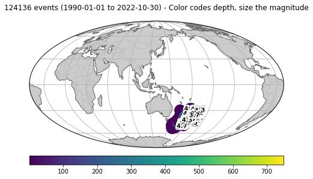

```python
cat_plot = cat1.plot(method='cartopy')
```

The required data from the catalog is then extracted as below

```python
magnitudes = [event.magnitudes[0].mag for event in cat1]
time = [event.origins[0].time.datetime for event in cat1]
depths = [event.origins[0].depth for event in cat1]
Latitudes = [event.origins[0].latitude for event in cat1]
Longitudes = [event.origins[0].longitude for event in cat1]
```

The dataframe version of the earthquake data is as below

```python
DataEQ = pd.DataFrame ({'magnitudes':magnitudes, 'time':time, 'depths':depths, 'Latitudes':Latitudes, 'Longitudes':Longitudes},
                   columns = ['magnitudes','time','depths','Latitudes','Longitudes'])
DataEQ
```

|  | magnitudes | time | depths | Latitudes | Longitudes |
| --- | --- | --- | --- | --- | --- |
| 0 | 4.3 | 2022-10-30 22:39:14.596 | 10000.0 | -30.9570 | -179.2322 |
| 1 | 4.6 | 2022-10-30 21:27:17.255 | 98806.0 | -33.7325 | 179.6401 |
| 2 | 4.5 | 2022-10-29 23:35:54.510 | 80015.0 | -42.0176 | 172.6593 |
| 3 | 5.5 | 2022-10-28 03:55:58.910 | 43000.0 | -35.6283 | -179.2027 |
| 4 | 4.7 | 2022-10-27 21:19:34.104 | 97590.0 | -38.6865 | 176.2185 |
| ... | ... | ... | ... | ... | ... |
| 124131 | 5.0 | 1990-01-02 01:36:35.400 | 221000.0 | -38.8504 | 175.1348 |
| 124132 | 3.7 | 1990-01-01 14:56:50.920 | 97900.0 | -40.1321 | 176.8986 |
| 124133 | 4.1 | 1990-01-01 12:31:12.570 | 192000.0 | -38.1385 | 176.7908 |
| 124134 | 3.9 | 1990-01-01 05:50:36.560 | 232000.0 | -36.9739 | 177.5577 |
| 124135 | 3.7 | 1990-01-01 03:10:34.670 | 151000.0 | -38.6069 | 176.1261 |

124136 rows × 5 columns

The times column data is seperated into actual time of occurence and the year.

```python
DataEQ['year'] = pd.DatetimeIndex(DataEQ['time']).year
DataEQ
```

|  | magnitudes | time | depths | Latitudes | Longitudes | year |
| --- | --- | --- | --- | --- | --- | --- |
| 0 | 4.3 | 2022-10-30 22:39:14.596 | 10000.0 | -30.9570 | -179.2322 | 2022 |
| 1 | 4.6 | 2022-10-30 21:27:17.255 | 98806.0 | -33.7325 | 179.6401 | 2022 |
| 2 | 4.5 | 2022-10-29 23:35:54.510 | 80015.0 | -42.0176 | 172.6593 | 2022 |
| 3 | 5.5 | 2022-10-28 03:55:58.910 | 43000.0 | -35.6283 | -179.2027 | 2022 |
| 4 | 4.7 | 2022-10-27 21:19:34.104 | 97590.0 | -38.6865 | 176.2185 | 2022 |
| ... | ... | ... | ... | ... | ... | ... |
| 124131 | 5.0 | 1990-01-02 01:36:35.400 | 221000.0 | -38.8504 | 175.1348 | 1990 |
| 124132 | 3.7 | 1990-01-01 14:56:50.920 | 97900.0 | -40.1321 | 176.8986 | 1990 |
| 124133 | 4.1 | 1990-01-01 12:31:12.570 | 192000.0 | -38.1385 | 176.7908 | 1990 |
| 124134 | 3.9 | 1990-01-01 05:50:36.560 | 232000.0 | -36.9739 | 177.5577 | 1990 |
| 124135 | 3.7 | 1990-01-01 03:10:34.670 | 151000.0 | -38.6069 | 176.1261 | 1990 |

124136 rows × 6 columns

```python
DataEQ.info()
```

```
<class 'pandas.core.frame.DataFrame'>
RangeIndex: 124136 entries, 0 to 124135
Data columns (total 6 columns):
 #   Column      Non-Null Count   Dtype
---  ------      --------------   -----
 0   magnitudes  124136 non-null  float64
 1   time        124136 non-null  datetime64[ns]
 2   depths      124110 non-null  float64
 3   Latitudes   124136 non-null  float64
 4   Longitudes  124136 non-null  float64
 5   year        124136 non-null  int64
dtypes: datetime64[ns](1), float64(4), int64(1)
memory usage: 5.7 MB
```

A simple exploratory study is taken to identify how the data is distributed and to determine possible relationships. From this plot, we can make a guess that majority of the erathquakes are small magnitude earthquake.

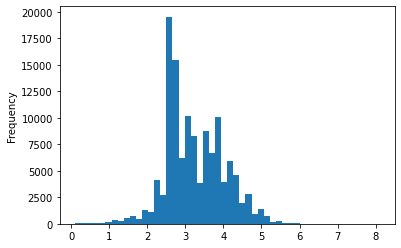

```python
DataEQ['magnitudes'].plot.hist(bins=50)
```

The plot below is to look at the distribution of earthquake with time. The trend in this plot is not so clear, however, there are features to look at such as the variations of the lower magnitude mark.

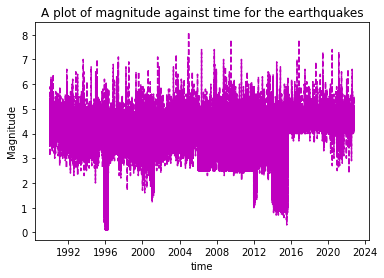

```python
plt.title('A plot of magnitude against time for the earthquakes')
plt.xlabel('time')
plt.ylabel('Magnitude')
plt.plot(time,magnitudes,'m--')
plt.show()
```

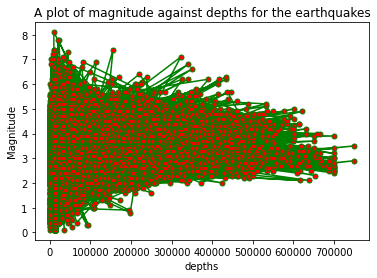

```python
plt.title('A plot of magnitude against depths for the earthquakes')
plt.xlabel('depths')
plt.ylabel('Magnitude')
plt.plot(depths,magnitudes,color = 'green',linestyle = 'solid', marker = '.',markerfacecolor = 'red', markersize = 10)
plt.show()
```

The mean and median magnitude of the earthquakes, the largest magnitude earthquake ever recorded in the region and the mean, median and largest predicted depths of the earthquakes are shown below. These help characterize the nature of earthquakes recorded in the region, i.e from the mean and median value of the magnitudes, we can infer that the region experinces mainly small magnitude earthquakes. However, majority of the earthquakes are relatively shallow with earthquakes as compared with average depth of the subduction linked earthquakes. This means that these earthquakes are influenced by the upper part of the subducting plates. This means they could have an effect on the plate motion.

```python
[DataEQ['magnitudes'].mean(), DataEQ['magnitudes'].median(), DataEQ['magnitudes'].max(), DataEQ['depths'].mean(), DataEQ['depths'].median(),
 DataEQ['depths'].max()]
```

```
[3.2373308307018114, 3.1, 8.1, 67002.97659334462, 31700.0, 750000.0]
```

From the below graph, we can infer that the mean magnitude of the earthquake is following a certain trend, it was reducing from 1990 up to around 2015, and then all of a sudden it has gone high.

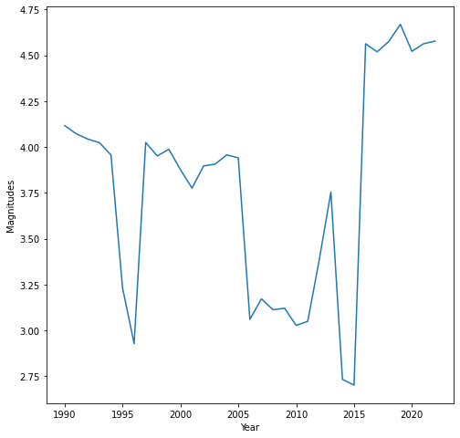

```python
Mag_df = (DataEQ.groupby(["year"])['magnitudes'].mean())
Mag_df.to_frame()
Mag_df.plot(x='year', y=['Magnitudes'], kind='line', figsize=(8,8))
plt.ylabel('Magnitudes')
plt.xlabel('Year')
plt.show()
```

The trend in the depth in the below graph shows us that majority of the recent earthquakes have been happening at shallower depths than before. This cxan be used to explain the tectonic regime of the region also show that the upper part of the plate could be becoming weaker. This would influence the motion of the plates (speed and direction).

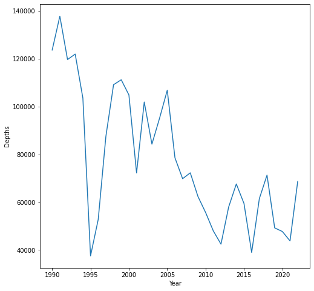

```python
Dep_df = (DataEQ.groupby(["year"])['depths'].mean())
Dep_df.to_frame()
Dep_df.plot(x='year', y=['depths'], kind='line', figsize=(8,8))
plt.ylabel('Depths')
plt.xlabel('Year')
plt.show()
```

$\textbf{Loading and anlysing second part of the data in the following cells:}$  
The unwanted columns showing the standard errors and locations in degrees, since the remaining columns give the same information in meters are removed.

```python
list_of_frams = []
variables = locals()
df = locals()
for i in range(1,11):
    variables["Station{0}".format(i)] = open(f'../DataSci Project/Station{i}.txt','r')
    df["df{0}".format(i)] = pd.read_fwf(f"Station{i}.txt")
    list_of_frams.append(variables["df{0}".format(i)])
```

```python
Datafram = pd. concat(list_of_frams)
Datafram.reset_index(inplace=True)
Datafram = Datafram.drop(columns=['index','week','d','yyyy.yyyy','_e0(m)','____n0(m)','u0(m)','__MJD','reflon','_ant(m)','sig_e(m)','sig_n(m)',
                                  'sig_u(m)','__corr_en','__corr_eu','__corr_nu','_latitude(deg)','_longitude(deg)','__height(m)'])
Datafram
```

|  | site | YYMMMDD | __east(m) | _north(m) | ____up(m) |
| --- | --- | --- | --- | --- | --- |
| 0 | AUCK | 95MAY31 | 0.542713 | -0.248693 | 0.700912 |
| 1 | AUCK | 95JUN01 | 0.540893 | -0.243142 | 0.691049 |
| 2 | AUCK | 95SEP18 | 0.534670 | -0.238254 | 0.680948 |
| 3 | AUCK | 95SEP19 | 0.530306 | -0.236401 | 0.677724 |
| 4 | AUCK | 95SEP20 | 0.534688 | -0.240542 | 0.697275 |
| ... | ... | ... | ... | ... | ... |
| 77513 | NLSN | 22NOV01 | 0.977123 | 0.004613 | 0.157049 |
| 77514 | NLSN | 22NOV02 | 0.979699 | 0.008698 | 0.174831 |
| 77515 | NLSN | 22NOV03 | 0.975346 | 0.005953 | 0.143550 |
| 77516 | NLSN | 22NOV04 | 0.982334 | 0.005556 | 0.141124 |
| 77517 | NLSN | 22NOV05 | 0.976357 | 0.006310 | 0.141200 |

77518 rows × 5 columns

The data is then cleaned and new columns defined for the time duration, displacements and the velocities of the GPS station which represent the motion of the plates.  
Xd, Yd and Yd are the displacements in the East-West, North-South and the vertical direction.  
Vh, Vz and Vt are the resultant horizontal component, vertical component and the resultant velocities of the GPS stations (plates) evaluated by dividing dispalcements with time durations, and taking appropriate mathematics for composite velocities.

```python
Datafram['YYMMMDD'] = pd.to_datetime(Datafram['YYMMMDD'], format='%y%b%d')
Datafram.rename(columns = {'YYMMMDD':'time','__east(m)':'Xd','_north(m)':'Yd','____up(m)':'Zd'}, inplace=True)
Datafram["year"] = pd.DatetimeIndex(Datafram["time"]).year
Datafram['time_dur'] = Datafram['time'].diff()
Datafram['time_dur'] = Datafram['time_dur'].dt.total_seconds().fillna(1000000)
Datafram["Horiz_disp"] = np.sqrt((Datafram["Xd"])**2 + (Datafram["Yd"])**2)
Datafram["Total_disp"] = np.sqrt((Datafram["Xd"])**2 + (Datafram["Yd"])**2 + (Datafram["Zd"])**2)
Datafram["Vh"] = (1000*Datafram['Horiz_disp'])/Datafram['time_dur']
Datafram["Vz"] = (1000*Datafram['Zd'])/Datafram['time_dur']
Datafram["Vt"] = (1000*Datafram['Total_disp'])/Datafram['time_dur']
```

```python
Datafram
```

|  | site | time | Xd | Yd | Zd | year | time_dur | Horiz_disp | Total_disp | Vh | Vz | Vt |
| --- | --- | --- | --- | --- | --- | --- | --- | --- | --- | --- | --- | --- |
| 0 | AUCK | 1995-05-31 | 0.542713 | -0.248693 | 0.700912 | 1995 | 1000000.0 | 0.596980 | 0.920686 | 0.000597 | 0.000701 | 0.000921 |
| 1 | AUCK | 1995-06-01 | 0.540893 | -0.243142 | 0.691049 | 1995 | 86400.0 | 0.593029 | 0.910622 | 0.006864 | 0.007998 | 0.010540 |
| 2 | AUCK | 1995-09-18 | 0.534670 | -0.238254 | 0.680948 | 1995 | 9417600.0 | 0.585352 | 0.897957 | 0.000062 | 0.000072 | 0.000095 |
| 3 | AUCK | 1995-09-19 | 0.530306 | -0.236401 | 0.677724 | 1995 | 86400.0 | 0.580612 | 0.892424 | 0.006720 | 0.007844 | 0.010329 |
| 4 | AUCK | 1995-09-20 | 0.534688 | -0.240542 | 0.697275 | 1995 | 86400.0 | 0.586303 | 0.911013 | 0.006786 | 0.008070 | 0.010544 |
| ... | ... | ... | ... | ... | ... | ... | ... | ... | ... | ... | ... | ... |
| 77513 | NLSN | 2022-11-01 | 0.977123 | 0.004613 | 0.157049 | 2022 | 172800.0 | 0.977134 | 0.989674 | 0.005655 | 0.000909 | 0.005727 |
| 77514 | NLSN | 2022-11-02 | 0.979699 | 0.008698 | 0.174831 | 2022 | 86400.0 | 0.979738 | 0.995214 | 0.011340 | 0.002024 | 0.011519 |
| 77515 | NLSN | 2022-11-03 | 0.975346 | 0.005953 | 0.143550 | 2022 | 86400.0 | 0.975364 | 0.985871 | 0.011289 | 0.001661 | 0.011411 |
| 77516 | NLSN | 2022-11-04 | 0.982334 | 0.005556 | 0.141124 | 2022 | 86400.0 | 0.982350 | 0.992435 | 0.011370 | 0.001633 | 0.011487 |
| 77517 | NLSN | 2022-11-05 | 0.976357 | 0.006310 | 0.141200 | 2022 | 86400.0 | 0.976377 | 0.986534 | 0.011301 | 0.001634 | 0.011418 |

77518 rows × 12 columns

Plots for the different components of the velocities are made and anlysed from the below cells.

```
array([[<matplotlib.axes._subplots.AxesSubplot object at 0x7f094dd477d0>],
      dtype=object)
```

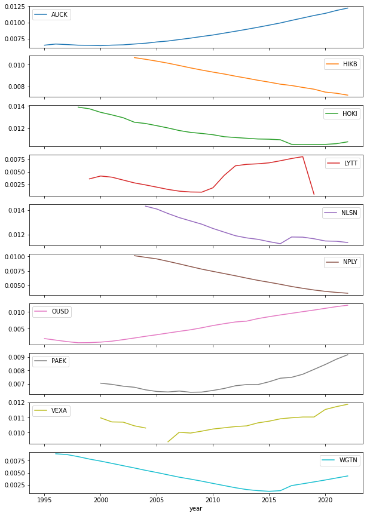

```python
pd.pivot_table(Datafram.reset_index(),
               index='year', columns='site', values='Vh'
              ).plot(subplots=True, layout=(10,1), figsize=(10,15))
```

The vertical components shows that some regions are on average stationary while some parts have had their trend going down meaning the plate is going downwards mostly from the Southern Island GPS stations.

```
array([[<matplotlib.axes._subplots.AxesSubplot object at 0x7f09880b8ed0>],
      dtype=object)
```

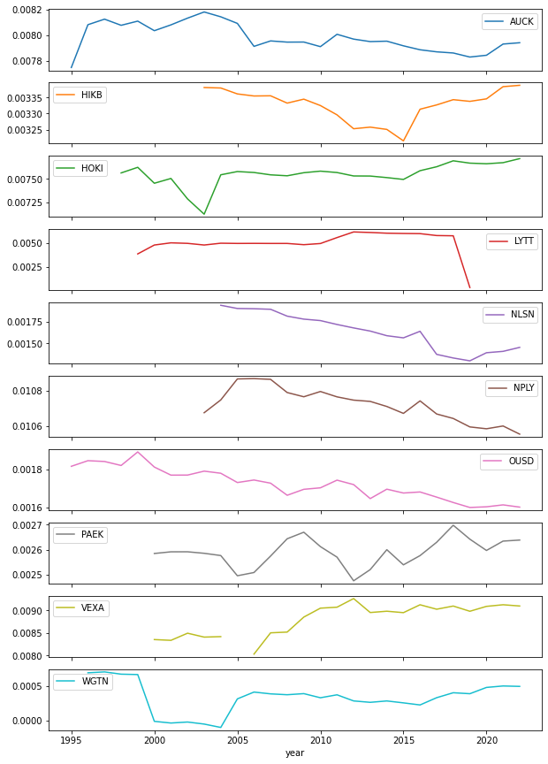

```python
pd.pivot_table(Datafram.reset_index(),
               index='year', columns='site', values='Vz'
              ).plot(subplots=True, layout=(10,1), figsize=(10,15))
```

```
array([[<matplotlib.axes._subplots.AxesSubplot object at 0x7f08ef492f50>],
      dtype=object)
```

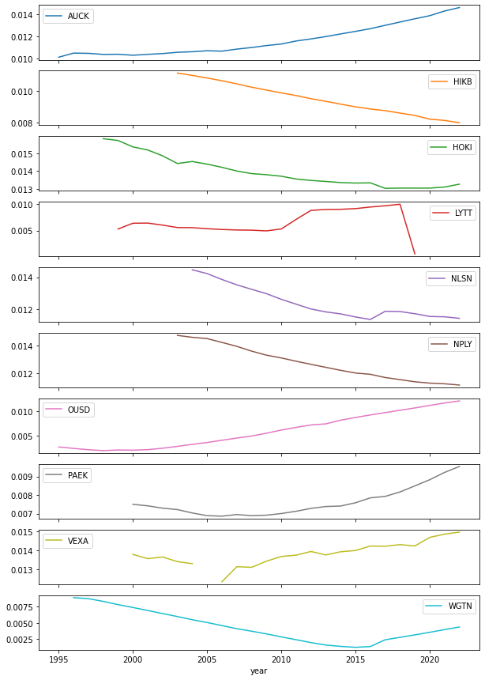

```python
pd.pivot_table(Datafram.reset_index(),
               index='year', columns='site', values='Vt'
              ).plot(subplots=True, layout=(10,1), figsize=(10,15))
```

The mean displacements for each stations are looked at from here:

```python
[Datafram.groupby(["site"])["Xd"].mean(),Datafram.groupby(["site"])["Yd"].mean(),Datafram.groupby(["site"])["Zd"].mean()]
```

```
[site
 AUCK    0.598025
 HIKB    0.291505
 HOKI   -0.917462
 LYTT   -0.201904
 NLSN    0.966067
 NPLY    0.302382
 OUSD   -0.359415
 PAEK   -0.546982
 VEXA   -0.896468
 WGTN    0.233343
 Name: Xd, dtype: float64, site
 AUCK    0.304439
 HIKB   -0.706388
 HOKI   -0.321337
 LYTT   -0.197820
 NLSN   -0.391888
 NPLY   -0.462537
 OUSD    0.255066
 PAEK   -0.094337
 VEXA   -0.159952
 WGTN   -0.128037
 Name: Yd, dtype: float64, site
 AUCK    0.691588
 HIKB    0.287657
 HOKI    0.654759
 LYTT    0.474002
 NLSN    0.141385
 NPLY    0.928501
 OUSD    0.149974
 PAEK    0.223965
 VEXA    0.781857
 WGTN    0.027990
 Name: Zd, dtype: float64]
```

The average velocities are also evaluated on a yearly basis but the trends are pretty much the same as the ones plotted above for the whole time period.

```
array([[<matplotlib.axes._subplots.AxesSubplot object at 0x7f0988ac8e10>],
      dtype=object)
```

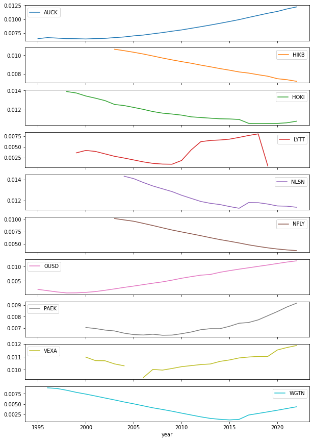

```python
Ave_Vh = Datafram.groupby(["site",'year'])["Vh"].mean()
Ave_Vh.to_frame()
pd.pivot_table(Ave_Vh.reset_index(), index='year', columns='site', values='Vh').plot(subplots=True, layout=(10,1), figsize=(10,15))
```